# Day 2：はじめてのオープンデータ処理（２）

# 準備

前回に引き続き「HEALTH.DATA.NY.GOV」で公開されている [Baby Names: Beginning 2007](https://health.data.ny.gov/Health/Baby-Names-Beginning-2007/jxy9-yhdk) を使います．

まずは拡張パッケージを読み込みます．

```r
if(!require(RCurl)){　# 拡張パッケージはインストールされているか？
  # 拡張パッケージのインストール
  install.packages("RCurl")
  # 拡張パッケージの読み込み
  library(RCurl)
}
```

```r
if(!require(ggplot2)){ # 拡張パッケージはインストールされているか？
  # 拡張パッケージのインストール
  install.packages("ggplot2")
  # 拡張パッケージの読み込み
  library(ggplot2)
}
if(!require(reshape2)){ # 拡張パッケージはインストールされているか？
  # 拡張パッケージのインストール
  install.packages("reshape2")
  # 拡張パッケージの読み込み
  library(reshape2)
}
```

# データの読み込み

データを読み込みます．

前回と同じようにURLからデータを読み込みます．

```
tmp <- getURL(url="https://health.data.ny.gov/api/views/jxy9-yhdk/rows.csv?accessType=DOWNLOAD",ssl.verifypeer = FALSE)
#CSV形式での読み込み
data <- read.csv(text=tmp)
```

# ウォーミングアップ

データを読み込んだら前回の課題にあったグラフを描いてみましょう．

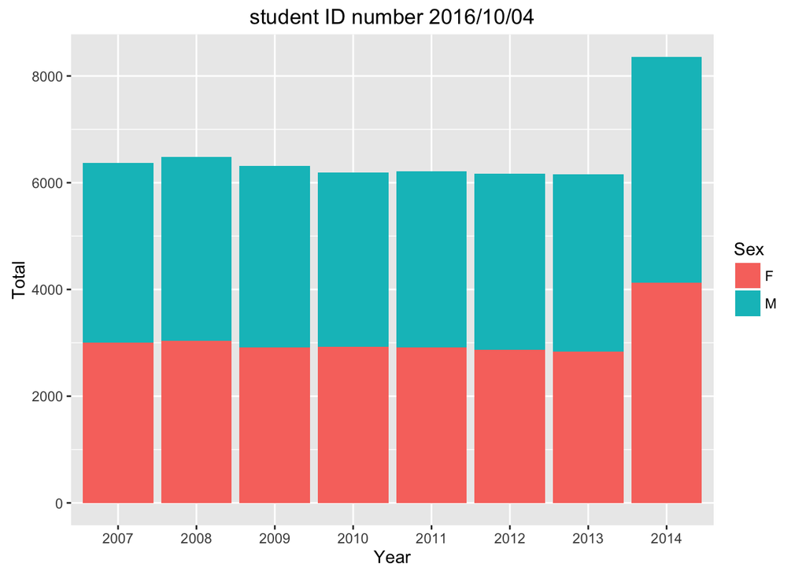

# グループ集計

前回は単純なクロス集計結果をグラフにしましたが， 正しい内容をグラフにしたものではありませんでした．

正しいグラフとするにはグループごとに正しく集計する必要があります．

こうしたケースの場合は aggregate 関数を利用できます．

```r
#性別(Sex)毎に件数(Count)を総計する
dat<-aggregate(x=c(data$Count),by=list(data$Sex),FUN=sum)
dat
```

```
##   Group.1      x
## 1       F 397693
## 2       M 545735
```

```r
#列名を付ける
colnames(dat)<-c("gender","total")
dat
```

```
##   gender  total
## 1      F 397693
## 2      M 545735
```

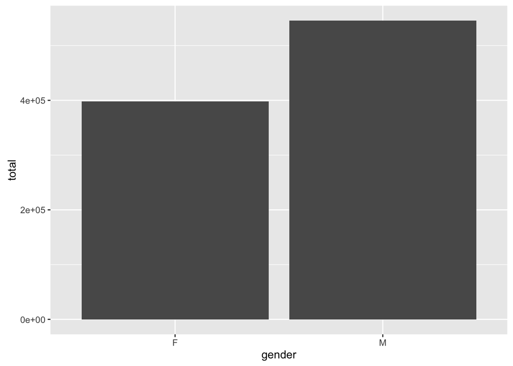

```r
ggplot(data = dat,mapping = aes(x=gender,y=total))+geom_bar(stat="identity")
```

グルーピングを複数指定する場合は以下のように記入します．

```r
aggregate(x=c(data$Count),by=list(data$Sex,data$Year),FUN=sum)
```

```
##    Group.1 Group.2     x
## 1        F    2007 50604
## 2        M    2007 69515
## 3        F    2008 49990
## 4        M    2008 70482
## 5        F    2009 49381
## 6        M    2009 69199
## 7        F    2010 48688
## 8        M    2010 67770
## 9        F    2011 48386
## 10       M    2011 66891
## 11       F    2012 47539
## 12       M    2012 66497
## 13       F    2013 47319
## 14       M    2013 64790
## 15       F    2014 55786
## 16       M    2014 70591
```

```r
aggregate(x=c(data$Count),by=list(data$Year,data$Sex),FUN=sum)
```

```
##    Group.1 Group.2     x
## 1     2007       F 50604
## 2     2008       F 49990
## 3     2009       F 49381
## 4     2010       F 48688
## 5     2011       F 48386
## 6     2012       F 47539
## 7     2013       F 47319
## 8     2014       F 55786
## 9     2007       M 69515
## 10    2008       M 70482
## 11    2009       M 69199
## 12    2010       M 67770
## 13    2011       M 66891
## 14    2012       M 66497
## 15    2013       M 64790
## 16    2014       M 70591
```

## 練習問題

### 調査年(Year)毎の人数推移をグラフにしてみよう

ヒント：aggregate 関数で data$Year 毎に件数を総計します

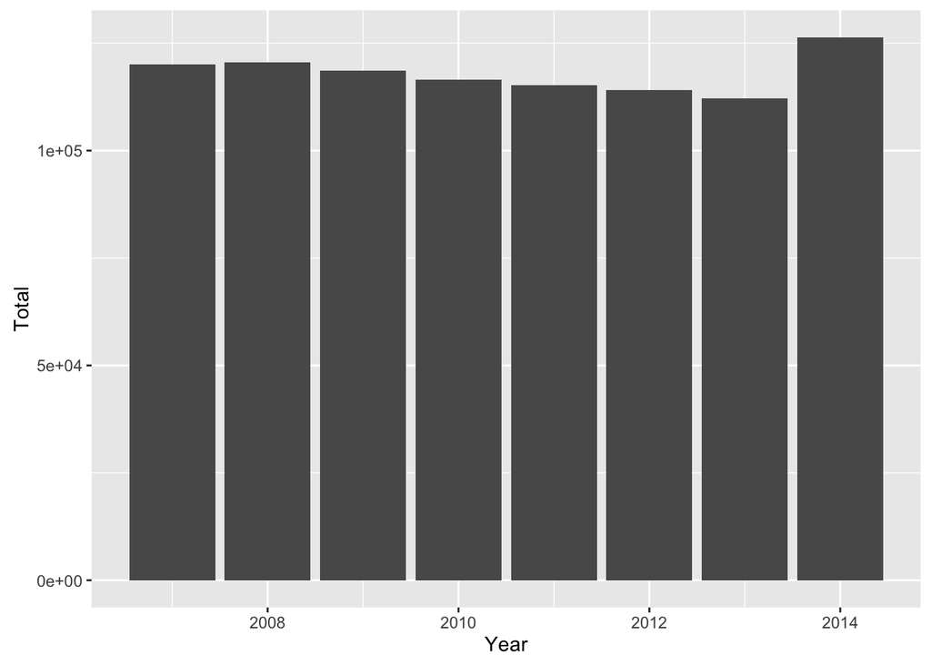

### 郡(County)毎の総数をグラフにしてみよう

ヒント：aggregate 関数で data$County 毎に件数を総計します．

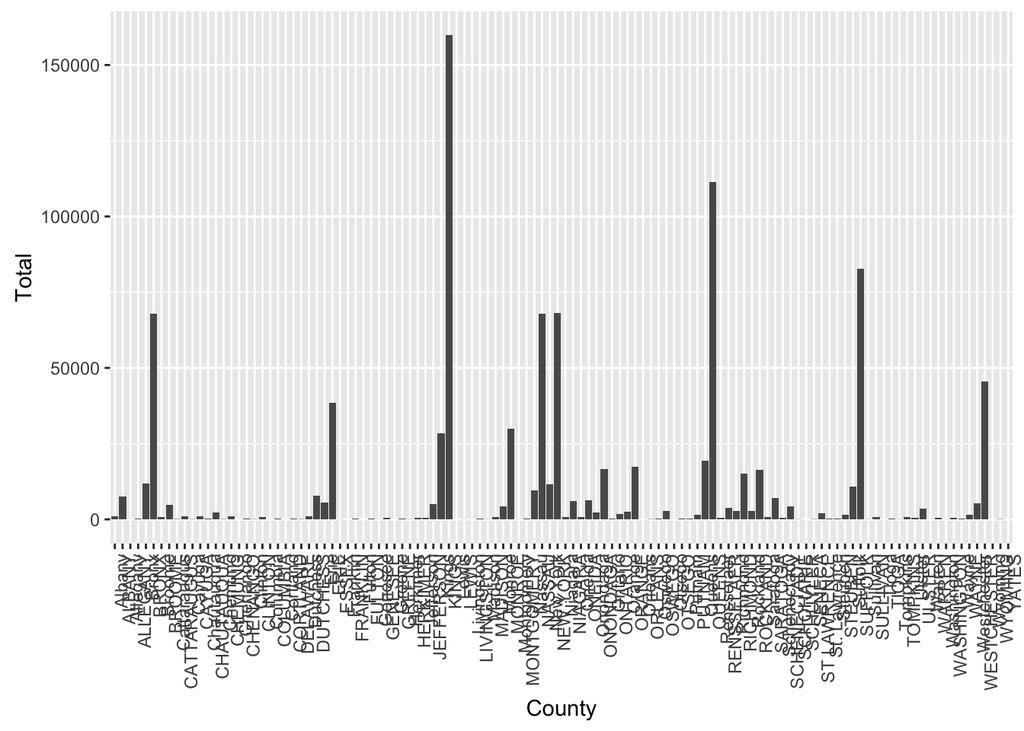

### 調査年(Year)毎の人数推移をグラフにしてみよう（性別の積み上げ）

ヒント：aggregate 関数で data$Year 毎に件数を総計します

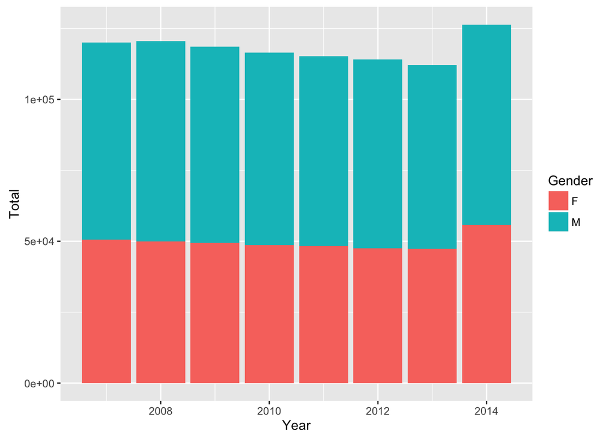

# ちょっとした分析

## 人気の名前トップ10

データをFirstName別に件数を集計します．

```r
#名前毎で件数を集計する
dat<-aggregate(x=c(data$Count),by=list(data$First.Name),FUN=sum)
#列名をつける
names(dat)<-c("name","count")
```

集計結果を降順に並び替えて上位10件を表示します．

```r
#並び替えを行う．idxには並び替え後のインデックスが格納される．
idx<-order(dat$count,decreasing=TRUE)
#内容確認
head(idx,n=3)
```

```
## [1] 1448  892  917
```

```r
#上位10位の表示
dat[idx,][1:10,]
```

```
##          name count
## 1448  MICHAEL 11565
## 892  ISABELLA 10207
## 917     JACOB 10008
## 1401  MATTHEW 10003
## 1882   SOPHIA  9874
## 984    JAYDEN  9869
## 1047   JOSEPH  9762
## 530    DANIEL  9336
## 698     ETHAN  9274
## 201   ANTHONY  9235
```

order 関数は並び替え後のインデックスを返す関数です．データフレームの並び替えに便利です．

上位10件をデータフレーム化します．

```r
#上位10件を取り出す
dat<-dat[order(dat$count,decreasing=TRUE),][1:10,]
#列名をつける
colnames(dat)<-c("name","total")
```

棒グラフを描画します．

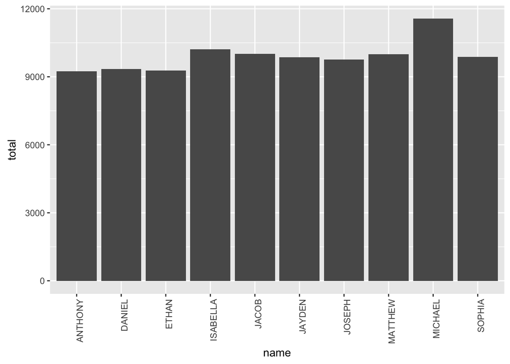

```r
#x軸にname，Y軸にtotalを設定する
g<-ggplot(dat,aes(x=name,y=total))
#棒グラフを設定する
g<-g+geom_bar(stat="identity")
#X軸ラベルを90度回転させる
g<-g+theme(axis.text.x = element_text(angle = 90, hjust = 1))
#描画
g
```

棒グラフの順番を変更します．人気順（昇順）に並び替えます．

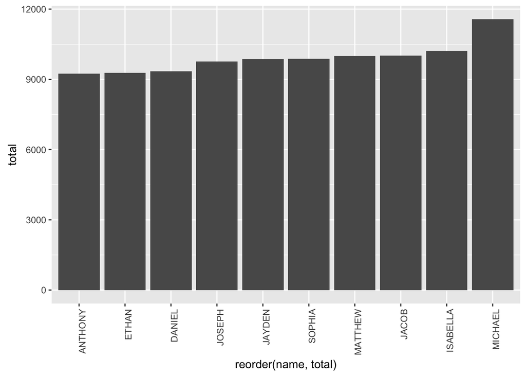

```r
#人気順（昇順）に並び替える
g<-ggplot(dat,aes(x=reorder(name,total),y=total))
#棒グラフを設定する
g<-g+geom_bar(stat="identity")
#X軸ラベルを90度回転させる
g<-g+theme(axis.text.x = element_text(angle = 90, hjust = 1))
#描画
g
```

X軸ラベルが変更されてしまったので直します．

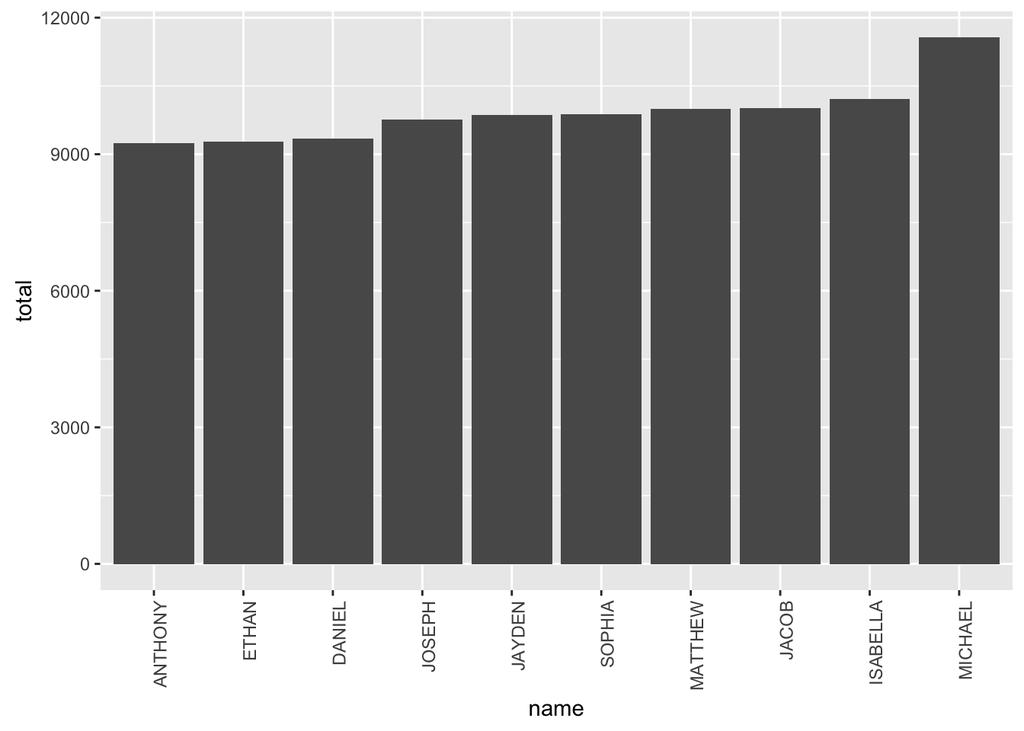

```r
g + labs(x="name")
```

棒グラフの順番を変更します．人気順（降順）に並び替えます．

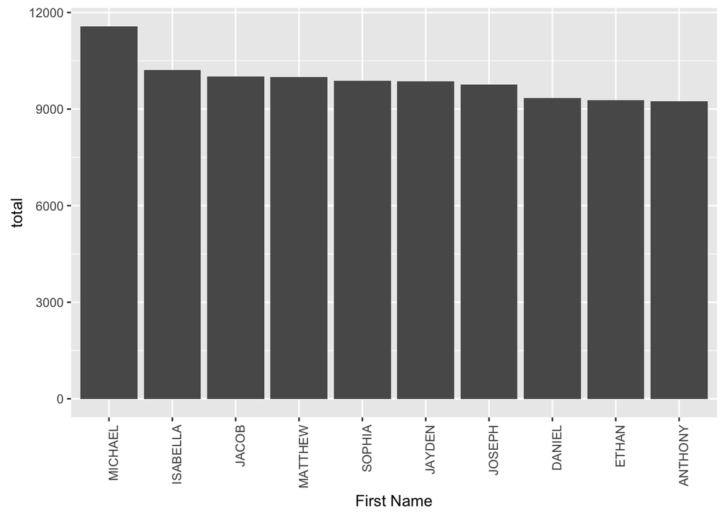

```r
#人気順（降順）に並び替える
g<-ggplot(dat,aes(x=reorder(name,-total),y=total))
#棒グラフを設定する
g<-g+geom_bar(stat="identity")
#X軸ラベルを90度回転させる
g<-g+theme(axis.text.x = element_text(angle = 90, hjust = 1))
g<-g+labs(x="First Name")
g
```

## 人気名の推移

今度は人気のある名前の変化を見てみます．

名前(First.Name)と調査年度(Year)をもとに集計する．

```r
#名前(First.Name)と調査年度(Year)に件数を集計します
dat<-aggregate(x=c(data$Count),by=list(data$First.Name,data$Year),FUN=sum)
#列名を付けます
colnames(dat)<-c("name","year","count")
```

特定の名前のデータだけ取り出します．（上位10位の名前のみ）

```r
tmp<-aggregate(x=c(data$Count),by=list(data$First.Name),FUN=sum)
#人気のある名前トップ10を取り出します
tmp<-tmp[order(tmp$x,decreasing=TRUE),][1:10,]
colnames(tmp)<-c("name","total")
#トップ10名にマッチする行を取り出します
d <- dat[dat$name %in% tmp$name,]
```

折れ線グラフにします．

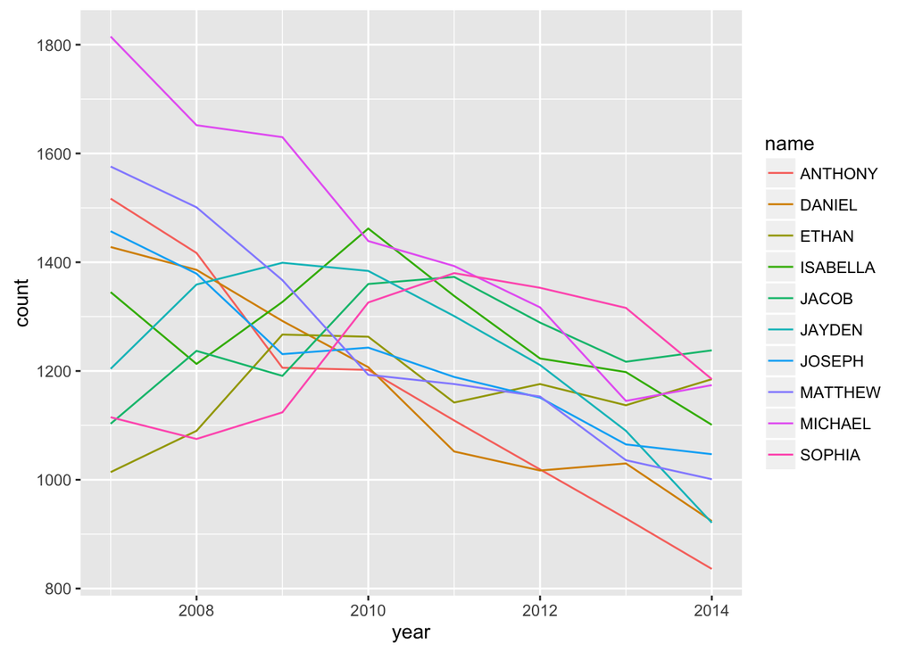

```r
#x軸にyearをY軸にcountを設定します．nameごとにグルーピングし，色も変更します
g<-ggplot(d,aes(x=year,y=count,group=name,colour=name))
#折れ線グラフを設定します
g<-g+geom_line()
#描画
g
```

色の違いだけでは見分けにくいので散布図にしてみます．

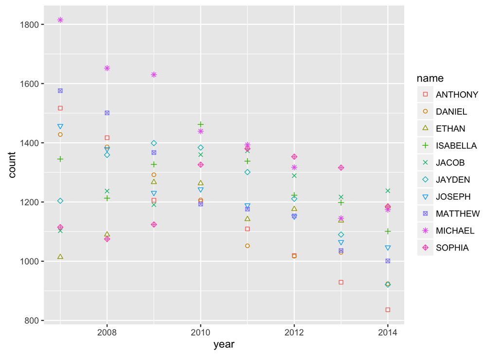

```r
#x軸にyearをY軸にcountを設定します．nameごとにグルーピングし，色・ポインタ形状も変更します
g<-ggplot(d,aes(x=year,y=count,group=name,colour=name,shape=name))
#散布図を設定します
g<-g+geom_point()
#形をmanualで指定します
g<-g+scale_shape_manual(values = 0:9)
g
```

折れ線グラフと散布図を合わせてみます．

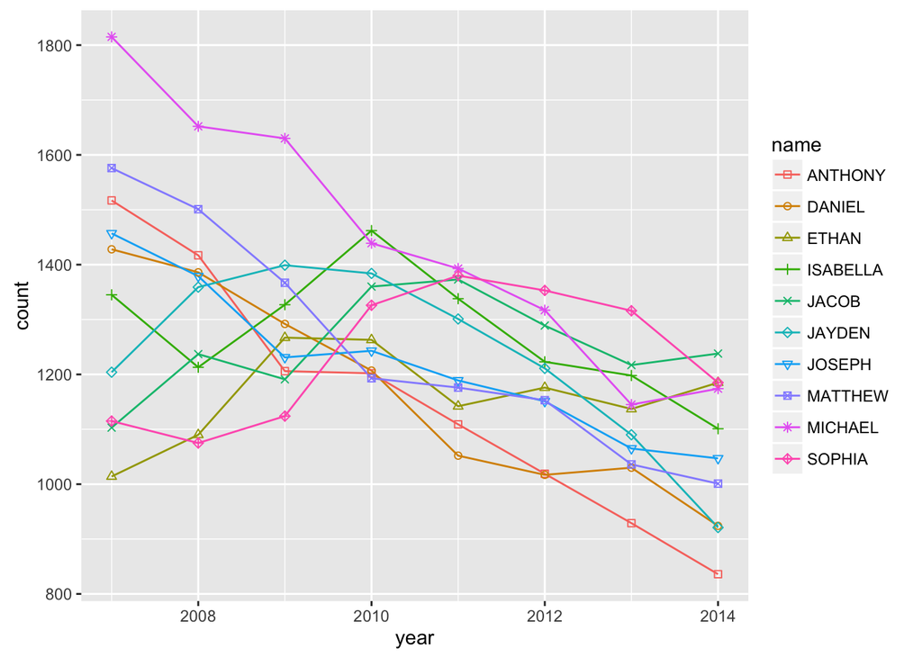

```r
#x軸にyearをY軸にcountを設定します．nameごとにグルーピングし，色・ポインタ形状も変更します
g<-ggplot(d,aes(x=year,y=count,group=name,colour=name,shape=name))
#折れ線グラフを設定します
g<-g+geom_line()
#散布図を設定します
g<-g+geom_point()
#マーカ形状をmanualで指定します
g<-g+scale_shape_manual(values = 0:9)
g
```

少しは見やすくなったかな． MICHAEL・MATTHEWの人気が下がっているなか， SOPHIAの人気が上がっているようにみえます．

## 人気名トップ10の推移

```r
dat<-aggregate(x=c(data$Count),by=list(data$First.Name,data$Year),FUN=sum)
colnames(dat)<-c("name","year","count")

#2007年のデータを取り出します
tmp <- dat[dat$year==2007,]
#上位10件を取り出します
d <- tmp[order(tmp$count,decreasing = TRUE),][1:10,]
d
```

```
##            name year count
## 753     MICHAEL 2007  1815
## 727     MATTHEW 2007  1576
## 93      ANTHONY 2007  1517
## 545      JOSEPH 2007  1457
## 254      DANIEL 2007  1428
## 882        RYAN 2007  1348
## 448    ISABELLA 2007  1345
## 224 CHRISTOPHER 2007  1322
## 799    NICHOLAS 2007  1212
## 499      JAYDEN 2007  1204
```

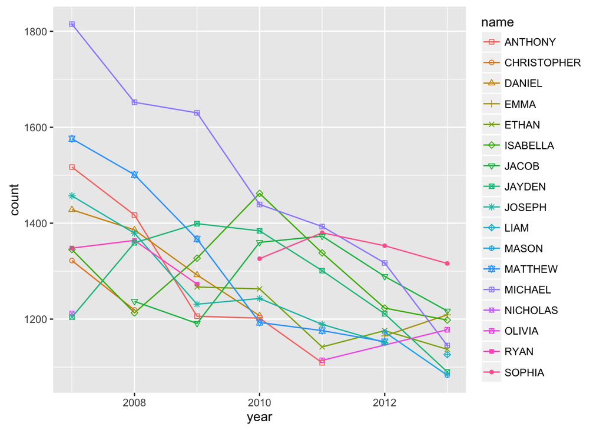

```r
#2008年のデータを取り出します
tmp <- dat[dat$year==2008,]
#上位10件を取り出し，先のデータフレームに追加します．
d<-rbind(d,tmp[order(tmp$count,decreasing = TRUE),][1:10,])
tmp <- dat[dat$year==2009,]
d<-rbind(d,tmp[order(tmp$count,decreasing = TRUE),][1:10,])
tmp <- dat[dat$year==2010,]
d<-rbind(d,tmp[order(tmp$count,decreasing = TRUE),][1:10,])
tmp <- dat[dat$year==2011,]
d<-rbind(d,tmp[order(tmp$count,decreasing = TRUE),][1:10,])
tmp <- dat[dat$year==2012,]
d<-rbind(d,tmp[order(tmp$count,decreasing = TRUE),][1:10,])
tmp <- dat[dat$year==2013,]
d<-rbind(d,tmp[order(tmp$count,decreasing = TRUE),][1:10,])

#グラフを描画します
g<-ggplot(d,aes(x=year,y=count,group=name,colour=name))
g<-g+geom_line()
g<-g+geom_point(aes(shape=name))
#マーカ形状を名前の種類数分用意します．unique 関数はデータを一意に変換する関数．ここでは名前の数を取得している．
g<-g+scale_shape_manual(values = seq(from=0,to=length(unique(d$name))-1))
g
```

2007年ダントツで人気があった「MICHAEL」は年代とともに落ち込んでいる． 全体的に落ち込んでいるようなので，より個性ある名前が好まれるようになった？？

## 2012年男女兼用名の集計

2012年度のデータから，男女ともに用いられる名前，男女兼用名を集計します．

2012年度のデータを取り出します．データフレームのサブセットを作成するには subset 関数を用います．

```r
#2012年データの抽出
sub <- subset(data,Year==2012)
```

取り出した2012年度のデータを男女別に分けます．

```r
#男性データの抽出
male <- sub[sub$Sex=="M",]
#女性データの抽出
female <- sub[sub$Sex=="F",]
#データの要約
summary(male)
```

```
##       Year          First.Name           County     Sex
##  Min.   :2012   MASON    :  45   KINGS      : 359   F:   0
##  1st Qu.:2012   LIAM     :  43   SUFFOLK    : 261   M:3292
##  Median :2012   JACOB    :  37   QUEENS     : 241
##  Mean   :2012   NOAH     :  37   NASSAU     : 237
##  3rd Qu.:2012   ALEXANDER:  33   WESTCHESTER: 194
##  Max.   :2012   JACKSON  :  33   ERIE       : 193
##                 (Other)  :3064   (Other)    :1807
##      Count
##  Min.   :  5.0
##  1st Qu.:  7.0
##  Median : 11.0
##  Mean   : 20.2
##  3rd Qu.: 21.0
##  Max.   :273.0
##
```

```r
summary(female)
```

```
##       Year         First.Name           County     Sex
##  Min.   :2012   SOPHIA  :  44   KINGS      : 384   F:2872
##  1st Qu.:2012   EMMA    :  42   SUFFOLK    : 300   M:   0
##  Median :2012   OLIVIA  :  37   NASSAU     : 270
##  Mean   :2012   ISABELLA:  35   QUEENS     : 244
##  3rd Qu.:2012   AVA     :  30   WESTCHESTER: 226
##  Max.   :2012   ABIGAIL :  29   ERIE       : 186
##                 (Other) :2655   (Other)    :1262
##      Count
##  Min.   :  5.00
##  1st Qu.:  6.00
##  Median : 11.00
##  Mean   : 16.55
##  3rd Qu.: 18.00
##  Max.   :204.00
##
```

男女別に名前をキーにしたCount列の合計を計算します．

```r
#名前をキーにCount列集計
m <- aggregate(male$Count,list(male$First.Name),sum)
names(m) <- c("name","cnt")
#名前をキーにCount列集計
f <- aggregate(female$Count,list(female$First.Name),sum)
names(f) <- c("name","cnt")
#データ確認(先頭3行だけ表示)
head(m[order(m$cnt,decreasing=TRUE),],n=3)
```

```
##        name  cnt
## 367 MICHAEL 1317
## 230   JACOB 1289
## 251  JAYDEN 1211
```

```r
head(f[order(f$cnt,decreasing=TRUE),],n=3)
```

```
##         name  cnt
## 547   SOPHIA 1353
## 268 ISABELLA 1223
## 197     EMMA 1165
```

男女別のデータで名前が一致する（=男女兼用名）のデータを結合します．

```r
#名前が一致する(=男女兼用名)データのみ結合
tmp <- merge(m,f,by="name")
names(tmp) <- c("name","male","female")
#男性への命名数が多い順に並び替え
tmp[order(tmp$male,decreasing=TRUE),]
```

```
##       name male female
## 9    DYLAN  816     18
## 3    ANGEL  361     14
## 12  JORDAN  329     25
## 7  CAMERON  317      7
## 6    BLAKE  209      6
## 1   ALEXIS   70    119
## 16   RILEY   70    227
## 5    AVERY   46    302
## 4    ARIEL   44     75
## 2    AMARI   38      5
## 11  HAYDEN   29     14
## 18  TENZIN   29     25
## 13  PEYTON   26    128
## 10 EMERSON   13     12
## 14 PHOENIX   12     10
## 15   QUINN   10     43
## 8    CASEY    6     14
## 17  SKYLER    5      6
```

ggplot用のデータフレームを作成します．

```r
#男性への命名数が多い順に並び替え
tbl <- tmp[order(tmp$male,decreasing=TRUE),]
#名前をキーにデータ再構成
tbl <- melt(tbl,id="name")
#確認
head(tbl)
```

```
##      name variable value
## 1   DYLAN     male   816
## 2   ANGEL     male   361
## 3  JORDAN     male   329
## 4 CAMERON     male   317
## 5   BLAKE     male   209
## 6  ALEXIS     male    70
```

※melt 関数は reshape2 に含まれる関数です． 関数が見つからないというエラーが出る場合は library(reshape2) を実行してください（インストールしていないのであれば install.packages(“reshape2”) を実行後）．

横棒グラフを描画します．

```r
#列名の確認
names(tbl)
```

```
## [1] "name"     "variable" "value"
```

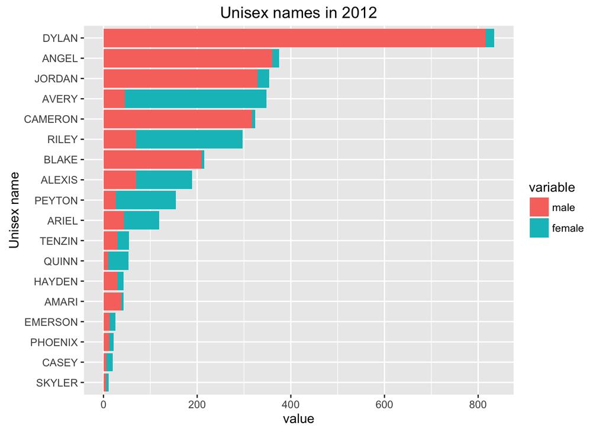

```r
#横棒グラフの描画
g <- ggplot(tbl,aes(x=reorder(name,value),y=value,fill=variable))
g <- g +geom_bar(stat="identity")+coord_flip()
g <- g+labs(x="Unisex name")+ggtitle("Unisex names in 2012")
g
```

グラフをファイル保存します．

```r
#グラフ画像の保存
ggsave(filename="tmp.png",plot=g)
```

```
#保存場所の確認
getwd()
```

### 解説

#### merge

二つのデータフレームを指定したキーを条件に結合します．

```r
#サンプルデータを作る
a<-data.frame(id=sample(1:10,5),type=sample(rep(c("A","B","C"),10),5))
b<-data.frame(id=sample(1:10,5),type=sample(rep(c("A","B","C"),10),5))
a
```

```
##   id type
## 1  4    A
## 2  2    A
## 3  5    B
## 4 10    C
## 5  8    B
```

```r
b
```

```
##   id type
## 1  7    B
## 2  4    A
## 3  9    B
## 4  5    B
## 5  2    A
```

```r
#id列をキーに統合する．idが一致する行を結合する
merge(x=a,y=b,by="id")
```

```
##   id type.x type.y
## 1  2      A      A
## 2  4      A      A
## 3  5      B      B
```

```r
#type列をキーに統合する．typeが一致する行を結合する
merge(x=a,y=b,by="type")
```

```
##    type id.x id.y
## 1     A    4    4
## 2     A    4    2
## 3     A    2    4
## 4     A    2    2
## 5     B    5    7
## 6     B    5    9
## 7     B    5    5
## 8     B    8    7
## 9     B    8    9
## 10    B    8    5
```

#### reshape2::melt

データフレームの複数列の値をカテゴリ変数1列と値1列の組に変換します．

```r
library(reshape2)
data("iris")
head(iris,n=3)
```

```
##   Sepal.Length Sepal.Width Petal.Length Petal.Width Species
## 1          5.1         3.5          1.4         0.2  setosa
## 2          4.9         3.0          1.4         0.2  setosa
## 3          4.7         3.2          1.3         0.2  setosa
```

```r
head(melt(iris,id="Species"))
```

```
##   Species     variable value
## 1  setosa Sepal.Length   5.1
## 2  setosa Sepal.Length   4.9
## 3  setosa Sepal.Length   4.7
## 4  setosa Sepal.Length   4.6
## 5  setosa Sepal.Length   5.0
## 6  setosa Sepal.Length   5.4
```

melt 関数は ggplot2 での作図の際によく利用されます．

## 練習問題

以下条件のグラフを描いてみよう．

### 人気の名前トップ20

ヒント：

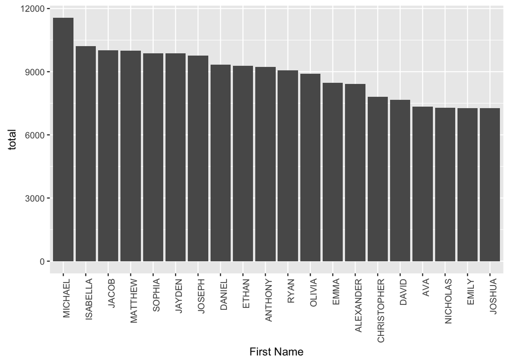

### 赤ちゃんの累積人数が多い郡トップ20

ヒント：

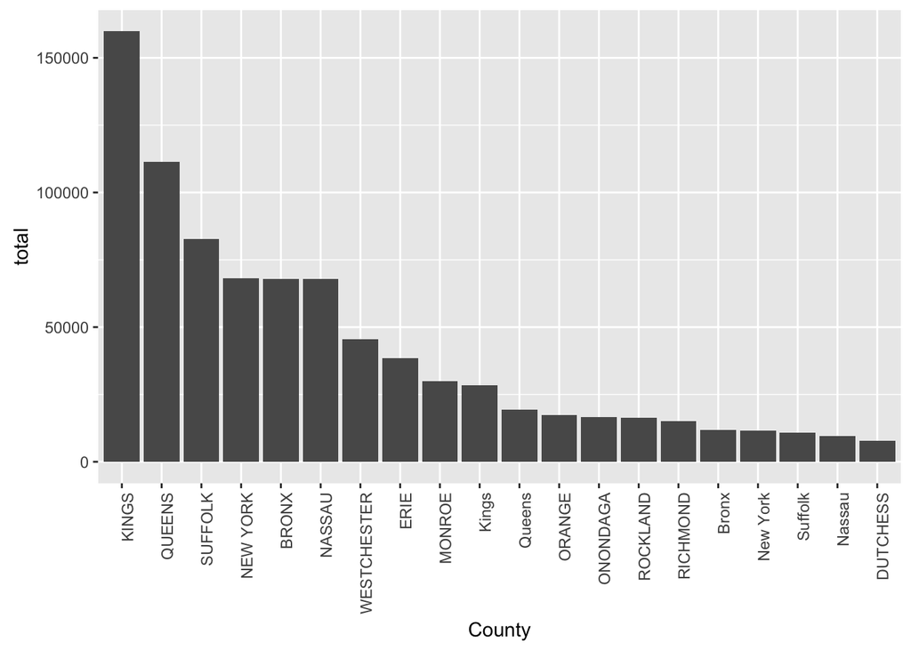

### 2010年の男女兼用名

ヒント：

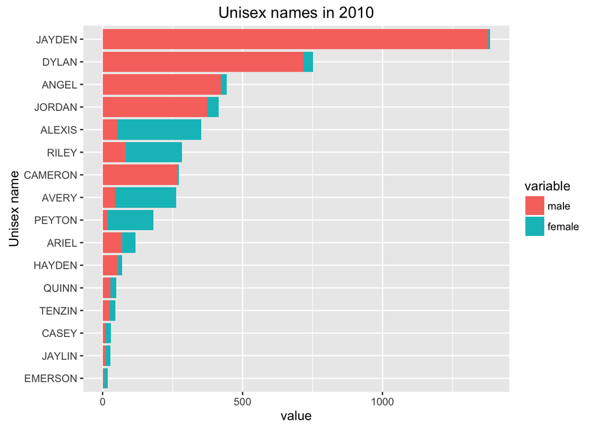

# 課題

「Baby Names: Beginning 2007」を用いて以下の条件のグラフを作成し，画像ファイルとして提出してください．グラフタイトルには自身の学籍番号を含めてください．

#### 1) 2013年度の名前ランキングトップ10がわかるグラフを作成してください．

回答イメージ

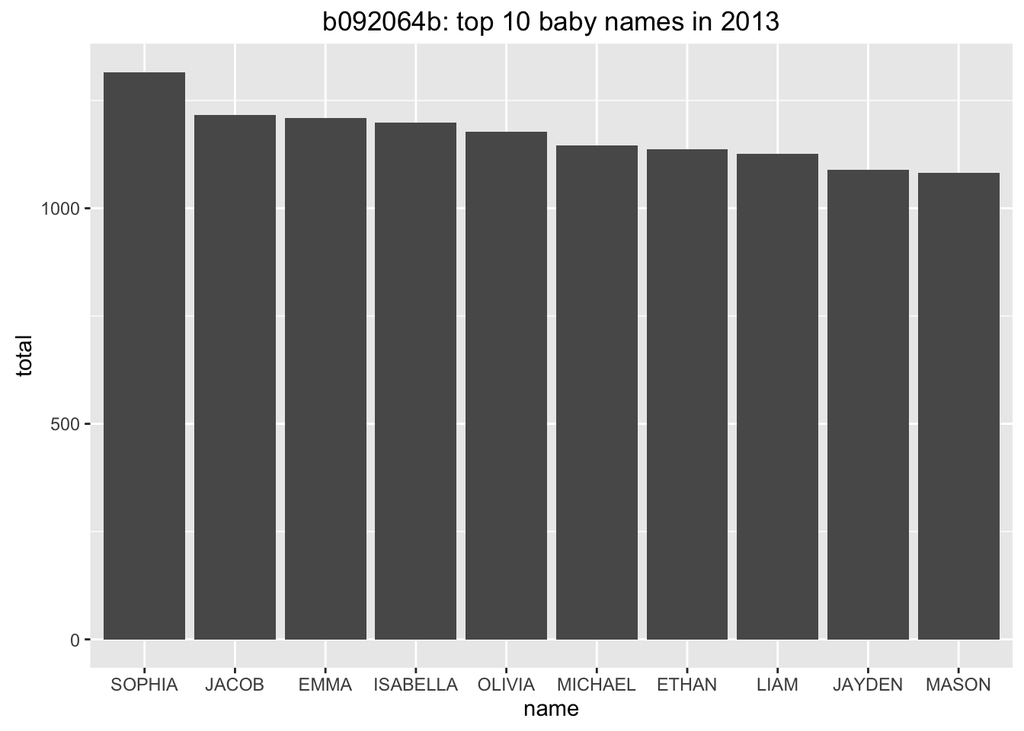

#### 2) 2007年度男女兼用名ランキング・男女の比率もわかるグラフを作成してください．

回答イメージ

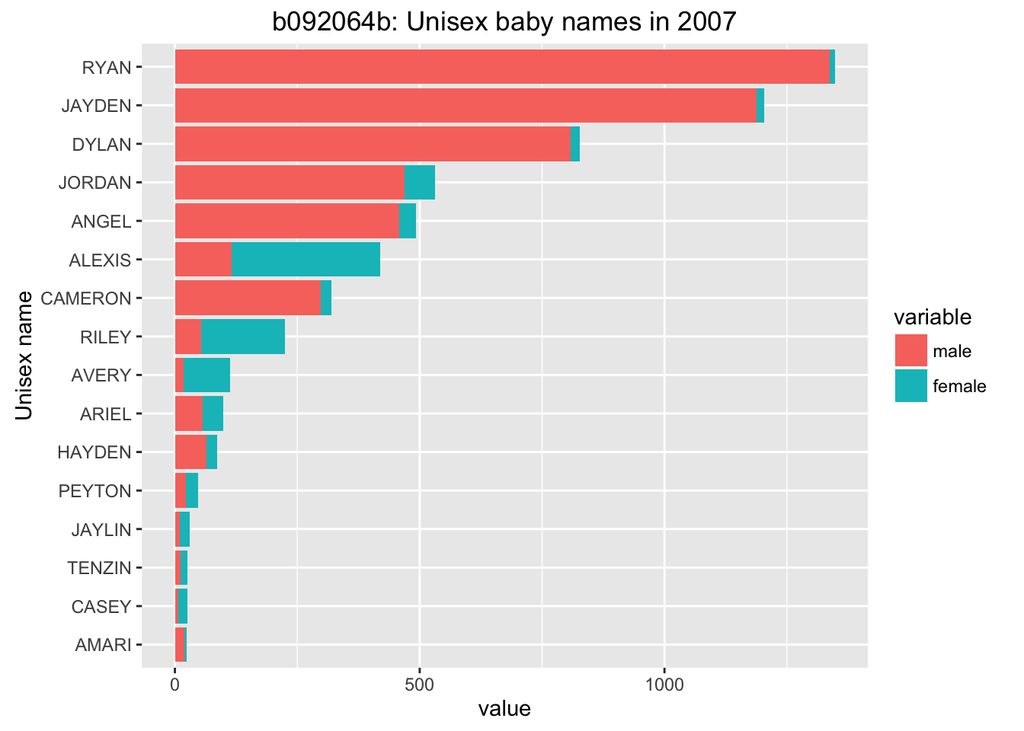

戻る

Masaharu Hayashi を著作者とするこの 作品 は [クリエイティブ・コモンズの 表示 4.0 国際 ライセンス](http://creativecommons.org/licenses/by/4.0/)で提供されています。